# Stat-rethink Chapter 4

```r
# the line is the most plausible line in the infinite universe of lines that the posterior distribution has considered.
```

Plotting regression intervals and countours

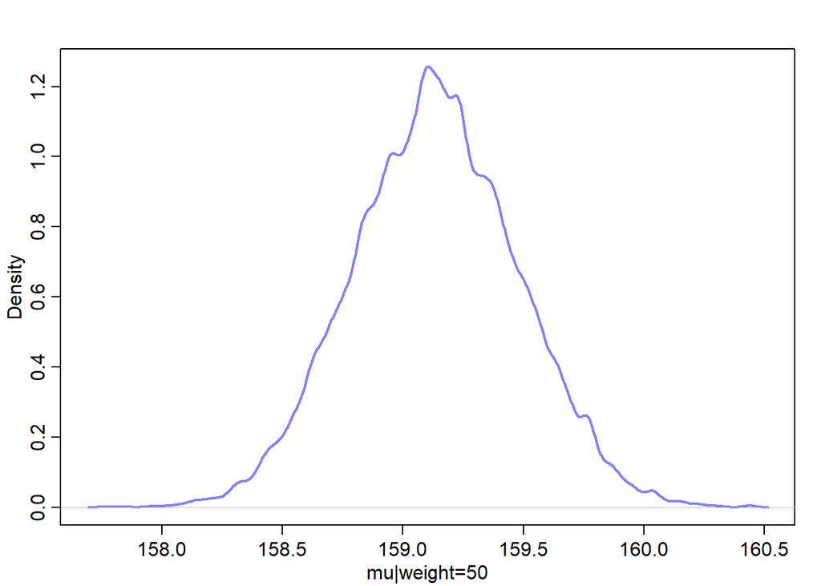

```r
post<-extract.samples(m4.3)
mu_at_50<- post$a + post$b*(50-xbar)
dens(mu_at_50, col=rangi2, lwd=2, xlab="mu|weight=50")
```

```r
PI(mu_at_50, prob=0.89)
```

```
##       5%      94%
## 158.5938 159.6879
```

```r
mu<-link(m4.3) #take the quap, sample it and compute mu for each case in the data and sample.
str(mu) # a big matrix of mu values. Each row is a sampe from the posterior.
```

```
##  num [1:1000, 1:352] 157 157 157 157 157 ...
```

```r
# Now, we want a distribution of mu for each weight value

weight.seq<-seq(from=25, to=70, by=1)
mu<-link(m4.3, data=data.frame(weight=weight.seq))
str(mu)
```

```
##  num [1:1000, 1:46] 136 136 136 136 137 ...
```

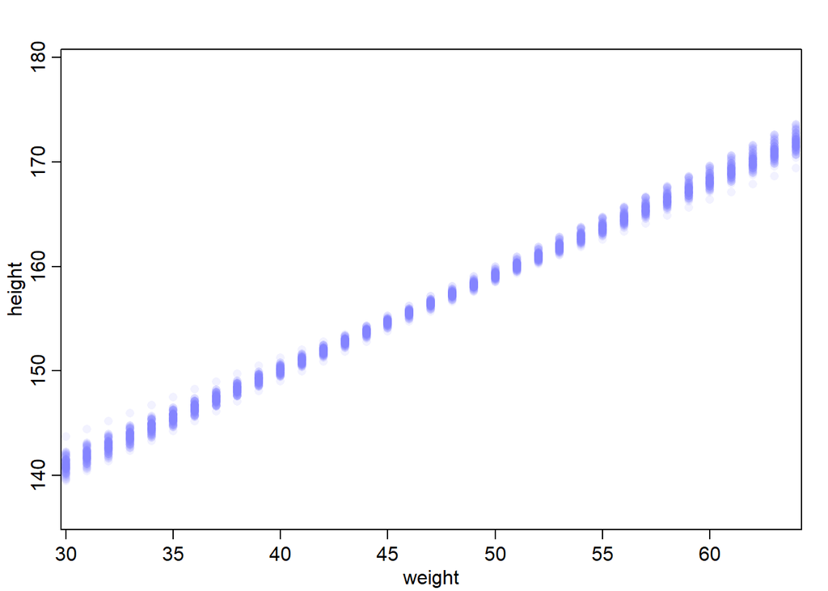

```r
plot(height~weight, d2, type ="n")
for (i in 1:100 )
points (weight.seq, mu[i, ], pch=16, col=col.alpha(rangi2,0.1))
```

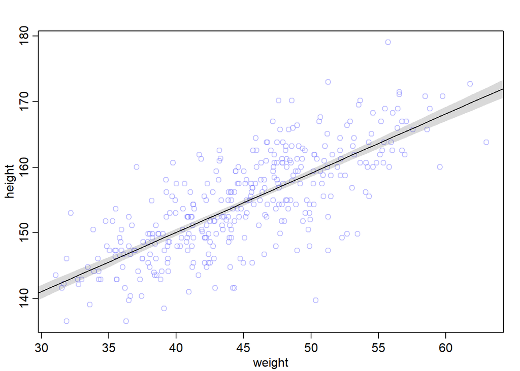

```r
mu.mean<-apply(mu, 2, mean)
mu.PI<-apply(mu, 2, PI, prob=0.89)
plot (height~weight, data=d2, col=col.alpha(rangi2, 0.5))
lines(weight.seq, mu.mean)
shade(mu.PI, weight.seq)
```

Prediction intervals: we want to incorporate uncertainty due to the first line of the model (h~N(mu, sigma)). We need to incorporate sigma in the predictions.

```r
sim.height<-sim(m4.3, data=list(weight=weight.seq))
str(sim.height) # is a matrix of simulated height
```

```
##  num [1:1000, 1:46] 132 139 127 139 129 ...
```

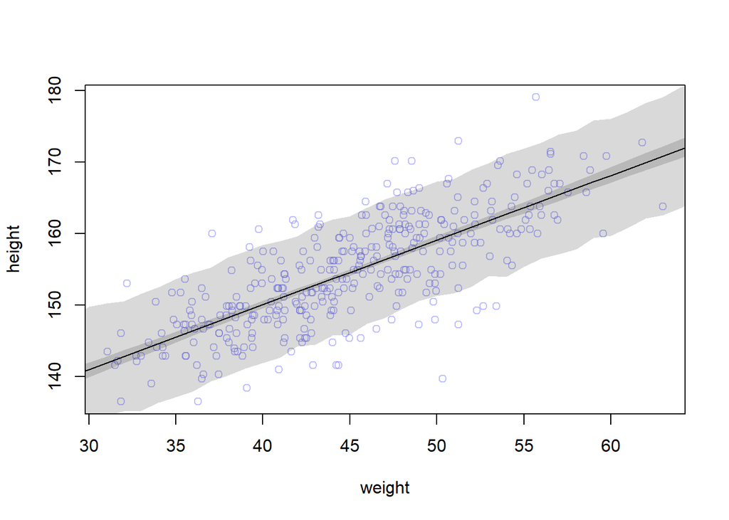

```r
height.PI<-apply(sim.height,2,PI, prob=0.89)
mu.HPDI<-apply(mu, 2, HPDI, prob=0.89)

plot(height~weight, d2, col=col.alpha(rangi2,0.5))
lines(weight.seq, mu.mean)
shade(mu.HPDI, weight.seq)
shade(height.PI, weight.seq)
```

## Curves from lines

There are two methods that use linear regression to build curves:

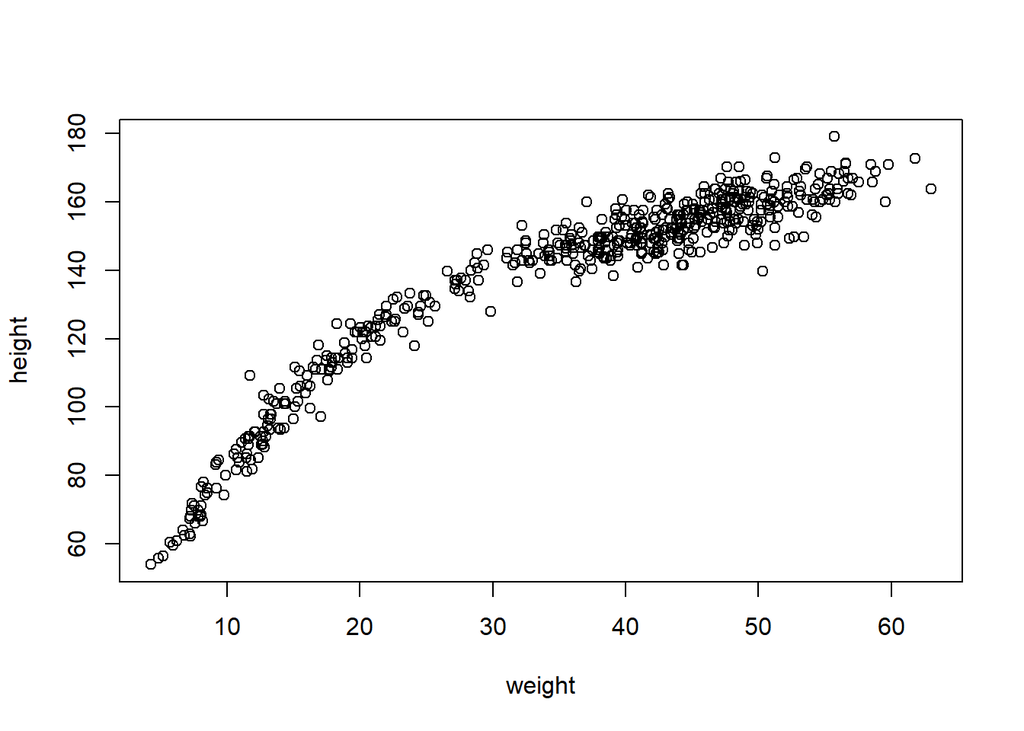

```r
d=Howell1
plot(height~weight, d) #non adults are included. # give a parabolic (second order) model of the mean
```

2. B-splines: is a smooth function build out of smaller component functions. Cherry-blossom data set:

```r
data("cherry_blossoms")
d<-cherry_blossoms
precis(d)
```

```
##                   mean          sd      5.5%      94.5%
## year       1408.000000 350.8845964 867.77000 1948.23000
## doy         104.540508   6.4070362  94.43000  115.00000
## temp          6.141886   0.6636479   5.15000    7.29470
## temp_upper    7.185151   0.9929206   5.89765    8.90235
## temp_lower    5.098941   0.8503496   3.78765    6.37000
##                                                                                                                           histogram
## year                       ▇▇▇▇▇▇▇▇▇▇▇▇▁
## doy                                                                ▁▂▅▇▇▃▁▁
## temp                                                               ▁▃▅▇▃▂▁▁
## temp_upper ▁▂▅▇▇▅▂▂▁▁▁▁▁▁▁
## temp_lower ▁▁▁▁▁▁▁▃▅▇▃▂▁▁▁
```

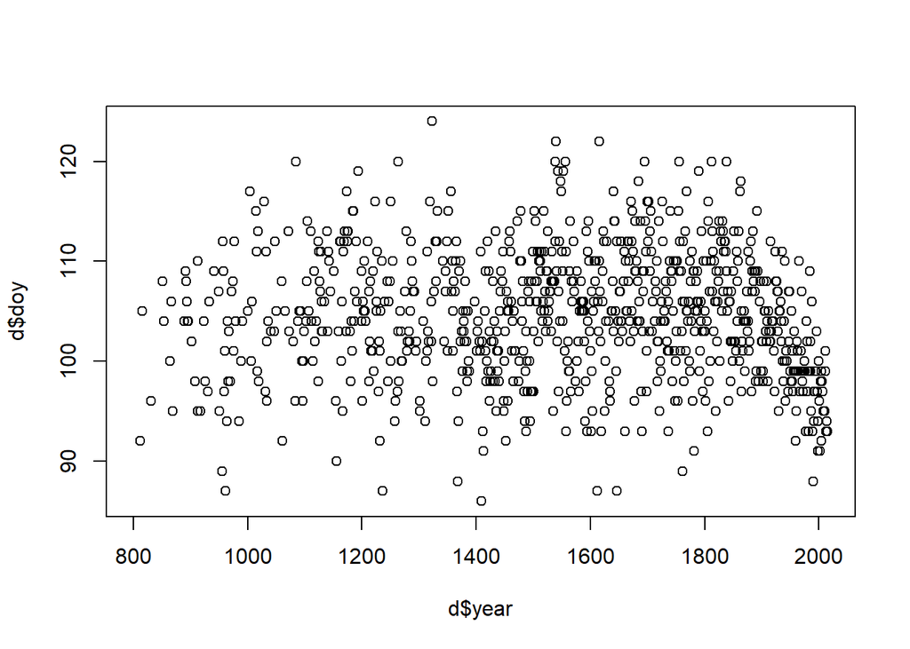

```r
plot(d$doy~d$year)
```

How we can extract a trend with b-spline? Divide predictor variable into parts. A parameter is assigned to each part.

## PRACTICE

### 4M1

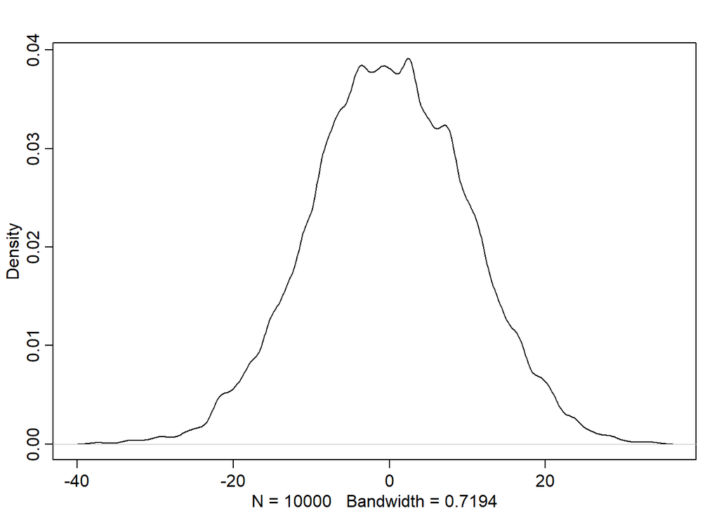

```r
sample2_mu<-rnorm(10000, 0, 10)
sample2_sigma<-rexp(10000, 1)
prior_y<-rnorm (10000, sample2_mu, sample2_sigma)
dens(prior_y)
```

### 4M2

```r
ylist<-alist(y ~ dnorm(mu, sigma),
             mu~dnorm(0,10),
             sigma~dexp (1)
             )
```

### 4M4

height_i~Normal (mu, sigma) mu_i= a + b*year_i a~Normal (178, 20) b~Normal (0.1, 0) sigma~Uniform (0, 50)

### 4M5

I do not think my priors change.

### 4M6

sigma~Uniform (0, 64)

### 4M7

```r
m4.3bis<-quap(alist(
height~dnorm(mu, sigma),
mu<-a+b*(weight),
a~dnorm(178,20),
b~dlnorm(0,1),
sigma~dunif(0,50)),
data = d2)

precis(m4.3bis)
```

```
##              mean         sd       5.5%       94.5%
## a     114.5335882 1.89774254 111.500629 117.5665473
## b       0.8907472 0.04175788   0.824010   0.9574844
## sigma   5.0727091 0.19124798   4.767058   5.3783603
```

```r
round(vcov (m4.3bis), 3)
```

```
##            a      b sigma
## a      3.601 -0.078 0.009
## b     -0.078  0.002 0.000
## sigma  0.009  0.000 0.037
```

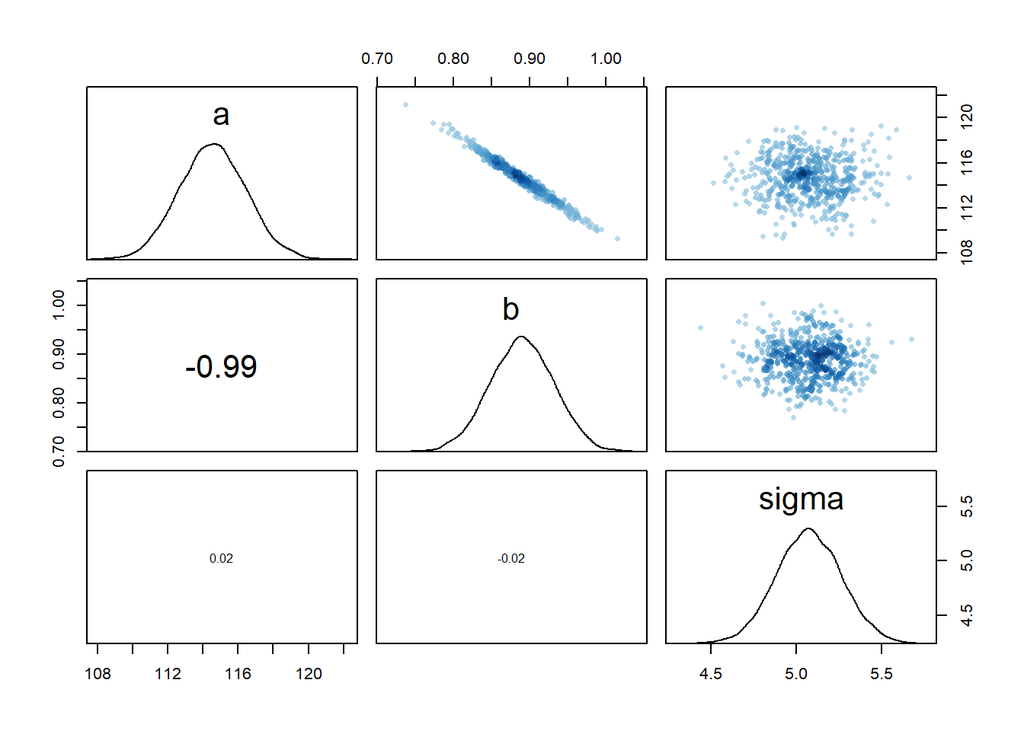

```r
pairs(m4.3bis)
```

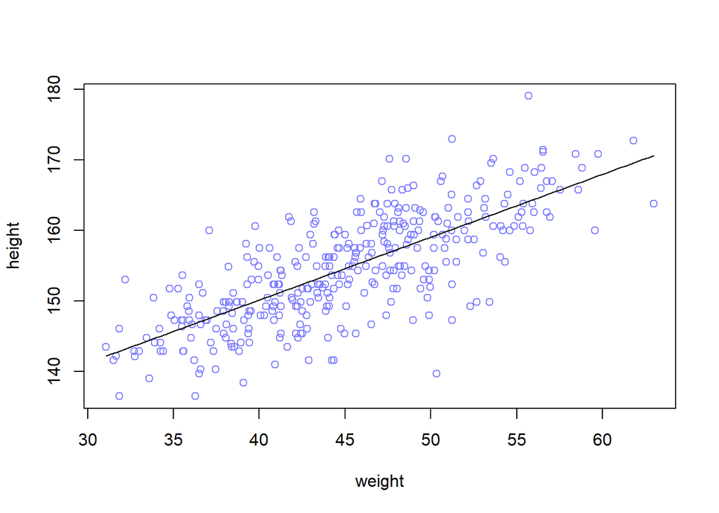

```r
plot(height~weight, data=d2, col=rangi2)
postbis<-extract.samples(m4.3bis)
a_mapbis<-mean(postbis$a)
b_mapbis<-mean(postbis$b)
curve(a_mapbis + b_mapbis*(x) , add=TRUE)
```

Mean and sd of the intercept (a) changed. Covariation between parameters exists. Posterior prediction looks the same.

### 4M8

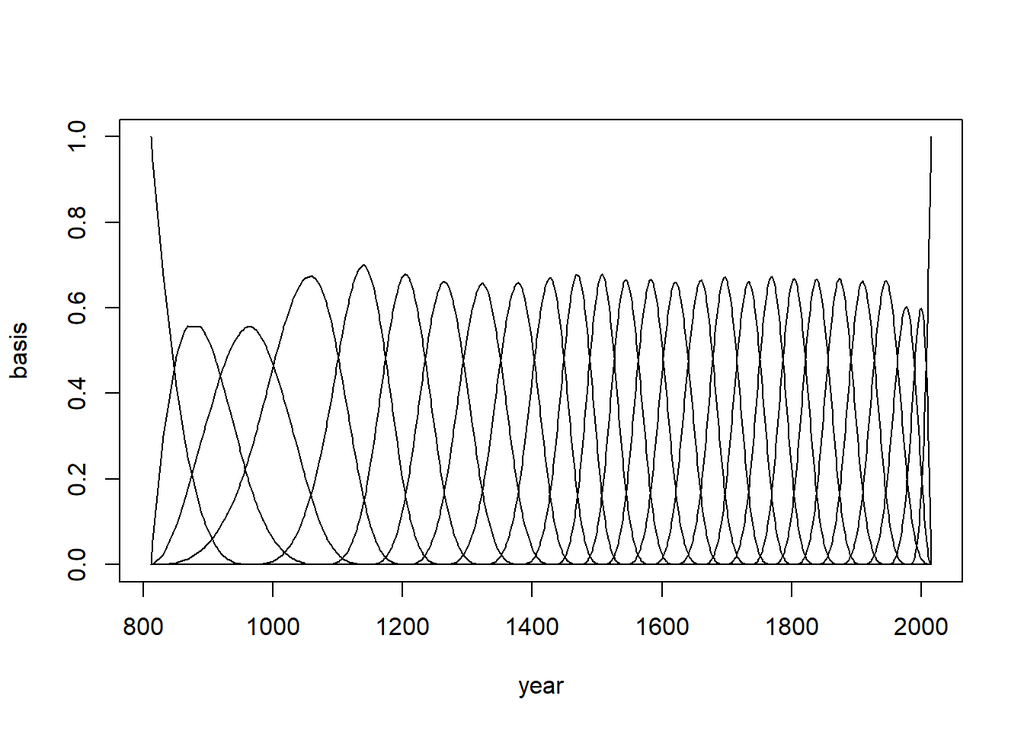

```r
d2<-d[complete.cases(d$doy) , ]
num_knots=25
knot_list=quantile (d2$year , probs = seq(0,1,length.out = num_knots))

library(splines)
B=bs(d2$year,
     knots = knot_list[-c(1,num_knots)] ,
     degree = 3 , intercept = TRUE)
plot(NULL , xlim=range(d2$year) , ylim=c(0,1) , xlab="year" , ylab="basis")
for (i in 1:ncol(B)) lines (d2$year , B[,i])
```